# Maps of Health Resource Distribution in Florida

[Rory Renzy](https://ncfpbl.github.io/author/rory-renzy/)

05/15/2020

# Overview and Data

During the fall semester, I wanted to capitalize on my interests in social policy by making some maps that show the distribution of health care resources in the state of Florida. This data is all publicly available through the Florida Department of Health’s [CHARTS](http://www.flhealthcharts.com/charts/default.aspx), or Community Health Assessment Resource Tool Set. The state collects a wealth of information on health outcomes, and makes it all public available in the form of `.csv` files. First, I will walk you through how to locate data on the website and use it to make maps. The above link will take you to the homepage, which provides avenues to all sorts of publicly available Florida health data.

[figure not shown]

I decided to choose the distribution of hospital beds, registered physicians, health care spending by public health departments, and the number of public health department employees. All of the data used in this report are from the most recently available uploads, from 2018. To locate these data, select `County Profiles` from the left-hand menu on the homepage, or [click here](http://www.flhealthcharts.com/ChartsReports/rdPage.aspx?rdReport=ChartsProfiles.CountyHealthProfile) to be brought directly to the page.

Firstly, appropriate packages must be installed and/or updated. Relavant packages include `tidyverse`, `tigris`, `rgeos`, `rdgal`, and `taRifx`. I then load in packages and read in my data. The original .xls files for this data were a little wonky, with some strange formatting that couldn’t easily be resolved in R. Therefore, I cleaned the spreadsheets for my various datasets, saved them as .csv files, and read them in that way. I would recommend this for future CHARTS use.

CHARTS data is formatted so that we must manually add fips codes for each of the counties so that the values in the dataset can be added to the appropriate areas on the map. I then replicate this for each dataset (results hidden). A sample chunk of code on how to do this for data is below.

```r
flhospitalbeds$fips_code <- recode(flhospitalbeds$County,
                         "Alachua" = 12001,
                         "Hamilton" = 12047,
                         "Okechobee" = 12093,
                         "Baker" = 12003,
                         "Hardee" = 12049,
                         "Orange" = 12095,
                         "Bay" = 12005,
                         "Hendry" = 12051,
                         "Osceola" = 12097,
                         "Bradford" = 12007,
                         "Hernando" = 12053,
                         "Palm Beach" = 12099,
                         "Brevard" = 12009,
                         "Highlands" = 12055,
                         "Pasco" = 12101,
                         "Broward" = 12011,
                         "Hillsborough" = 12057,
                         "Pinellas" = 12103,
                         "Calhoun" = 12013,
                         "Holmes" = 12059,
                         "Polk" = 12105,
                         "Charlotte" = 12015,
                         "Indian River" = 12061,
                         "Putnam" = 12107,
                         "Citrus" = 12017,
                         "Jackson" = 12063,
                         "Santa Rosa" = 12113,
                         "Clay" = 12019,
                         "Jefferson" = 12065,
                         "Sarasota" = 12115,
                         "Collier" = 12021,
                         "Lafayette" = 12067,
                         "Seminole" = 12117,
                         "Columbia" = 12023,
                         "Lake" = 12069,
                         "St. Johns" = 12109,
                         "Miami-Dade" = 12086,
                         "Lee" = 12071,
                         "St. Lucie" = 12111,
                         "DeSoto" = 12027,
                         "Leon" = 12073,
                         "Sumter" = 12119,
                         "Dixie" = 12029,
                         "Levy" = 12075,
                         "Suwannee" = 12121,
                         "Duval" = 12031,
                         "Liberty" = 12077,
                         "Taylor" = 12123,
                         "Escambia" = 12033,
                         "Madison" = 12079,
                         "Union" = 12125,
                         "Flagler" = 12035,
                         "Manatee" = 12081,
                         "Volusia" = 12127,
                         "Franklin" = 12037,
                         "Marion" = 12083,
                         "Wakulla" = 12129,
                         "Gadsden" = 12039,
                         "Martin" = 12085,
                         "Walton" = 12131,
                         "Gilchrist" = 12041,
                         "Monroe" = 12087,
                         "Washington" = 12133,
                         "Glades" = 12043,
                         "Nassau" = 12089,
                         "Gulf" = 12045,
                         "Okaloosa" = 12091)
```

# Making the Map

Now, the fun part: actually drawing the maps! Next, the FL shapefiles need to be loaded and fortified to create the outline for the maps.

```r
library(dplyr)
library(tigris)
```

Since the data we are using involves mapping into county shapefiles, we use the below code to pull down the FL county shapefiles from the `tigris` package.

```r
florida_counties <- counties(12, cb=TRUE)
```

We conclude this section by making our shapefiles usable, by `fortifying` them.

```r
library(rgeos)
library(rgdal)
library(taRifx)

florida_counties$fips <- destring(florida_counties$GEOID)
fortified_fl_counties <- fortify(florida_counties, region = "fips")
```

Lastly, I create my maps using ggplot2 code. The first map has sample code for constructing all of the maps - the style can be repeated throughout by changing the data, scales, etc.

## Hospital Beds

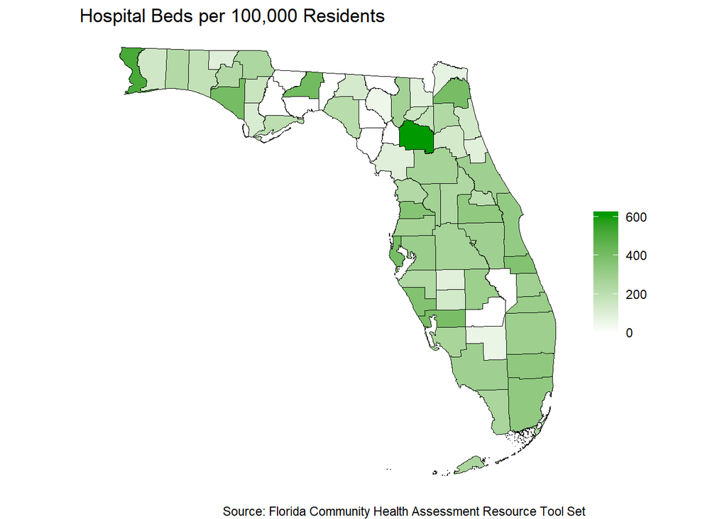

```r
ggplot() +
  geom_map(
    data = flhospitalbeds,
    aes(map_id = fips_code, fill = Rate),
    map = fortified_fl_counties
  ) +
  expand_limits(
    x = fortified_fl_counties$long,
    y = fortified_fl_counties$lat
  ) +
  geom_polygon(
    data = fortified_fl_counties,
    aes(x = long, y = lat),
    color = "black",
    fill = NA,
    group = fortified_fl_counties$group,
    size=.25
  ) +
  scale_fill_gradient(
    high = "#009900",
    low = "#ffffff",
    guide = "colourbar",
    limits = c(0, 612.3),
    name = ""
  ) +
  coord_map(
    "lambert",
    parameters = c(30,40)
  ) +
  theme_void() +
  labs(
    title = "Hospital Beds per 100,000 Residents",
    caption = "Source: Florida Community Health Assessment Resource Tool Set")
```

Since we see that Alachua County is likely skewing the entire scale, we can duplicate the `flhospitalbeds` dataframe and make this county “missing” to proxy for assessing the scale without its presence. We can then create the map again and see how the shading along the scale changes.

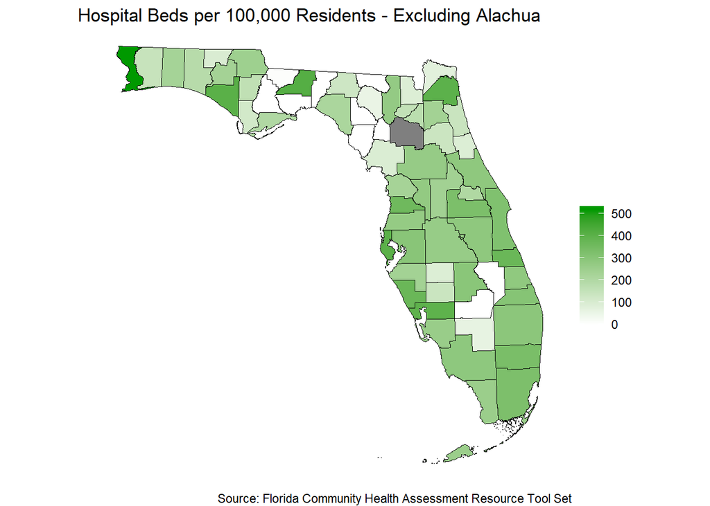

```r
hb_alachua <- flhospitalbeds
hb_alachua$Rate[hb_alachua$County=="Alachua"] <- NA
```

While this confirms that Alachua is a strange case, other counties (like Escambia and Leon) also have fairly high levels of hospital beds per 100,000 residents. Therefore, I theorize excluding Alachua in the next `Physicians` example will be more useful, since the discrepancies are much larger.

## Physicians

This is, by far, the area that has the most supplementary information available on it. The annual Physician Workforce Annual Report published by the Florida Department of Health is a great indicator of where the state currently stands on physician distribution. One-third of all licensed physicians in Florida are concentrated in the three populous South Florida counties (Palm Beach, Broward, and Miami-Dade). Conversely, only a staggering **two** percent of Florida physicians work in the state’s twenty most rural counties. The key in analyzing this issue, as with other political issues centered around geography, is to consider “rural” as a distinct underserved population category. The state classifies the rural areas, mostly located along the Panhandle or on the Bend around the Gulf, in this manner. The difference between rural and non-rural counties here is even starker than in the hospitals example above. Again, Alachua County is well-equipped with many physicians.

Part of the state’s mission is to use concrete policies to recruit and retain physicians to work in these areas, usually as part of a visa extension qualification or as prerequisite for loan forgiveness (although the reality of this might not be living up to the promise). In fact, many of the physicians that work in rural areas in Florida grew up in rural areas or were raised in a foreign-born country (or went to medical school in one) (Brooks, Mardon, & Clawson, 2003). Thus, in continuing that trend, one of the policies the state is working to establish is to identify health clinics in rural communities that medical students either interested in serving underserved communities or needing to for whatever state requirements could be cycled in and out for primary care training and work. This extends nationally, where the state is also trying to partner with the federal Health Resources and Services Administration, whose goal it is to provide medical services to those uninsured and/or in traditionally underserved areas.

A broader concern of distribution of physicians is why many doctors are not going to work in rural counties in the first place. Rechovsky and Staiti (2005) argue that it is not that rural counties have inadequate levels of physician care for the care requested, but rather that physicians are drawn to the more urban life of cities and populous counties, where job opportuniies are more plentiful, demand for services is “virtually limitless,” and private insurance pays well (Newhouse, 1990). This can create a “death spiral.” Some doctors are disincentivized by the fact that populations in rural counties rely more and more on lower-paying payments from public programs, like Medicaid and Medicare. Folks in rural areas continue to vote conservatively for representatives that have in their interest a further shrinking of the size of government, and this further disincentivizes doctors from moving to these areas, as public payments are lessened. In fact, many physicians across the state do not even accept Medicaid because of lower compensation compared to private health insurance (2019 Physician Workforce Annual Report, 2019). Therefore, it seems as though individual physician preferences need to be taken into consideration here as well. While rural doctors may work longer hours, their targeted care is not overly burdensome, and their likely place as a primary practice doctor (often all that is available in rural areas) can allow them to have a kind of medical monopoly (Rechovsky & Staiti, 2005). With increased purchasing power in rural areas, due to lower costs of living, it will be interesting to see if state and federal governmental programs can incentivize doctors to practice in these underserved communities.

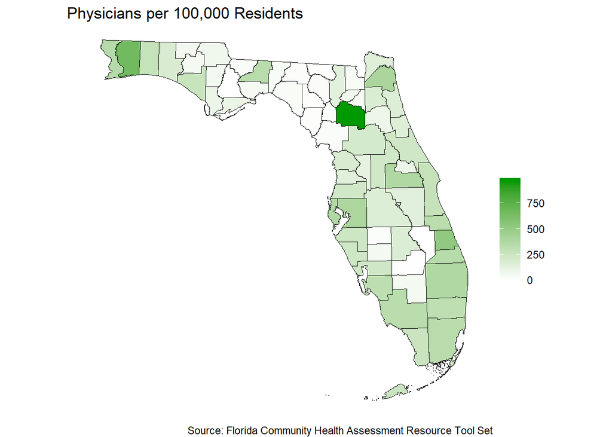

```r
phy_alachua <- flphysicians
phy_alachua$Rate[phy_alachua$County=="Alachua"] <- NA
phy_alachua$Rate[phy_alachua$County=="Santa Rosa"] <- NA
```

I again drop Alachua, as well as the skewing Santa Rosa county.

[figure not shown]

## Expenditures

The previous section on physician distribution may provide insight into this one. We see that the areas that are typically considered to be “rural” have a higher level of public health department funding per capita than more populous cities. Is this because there is more investment in these areas, or is the type of governmental investment different? I argue the latter. Since many of these counties, including Liberty, only have one or a few community health centers, it is not unreasonable to assume that medical professional salaries (such as those of nurses) and medical facility upkeep is skewing this metric in the favor of rural counties, whereas this is not the case in the more private practice-centered urban areas of the state. Of course, it is also the case in rural counties that the focus of county public health department dollars is different, more centered around “rural” issues. We saw this in things listed on the Liberty County public health department website, like “Dead Bird Removal” and “Mobile Home Parks” regulations. Liberty ounty never got back to me regarding the provision of a detailed budget file. Exploring this further in the future would be interesting.

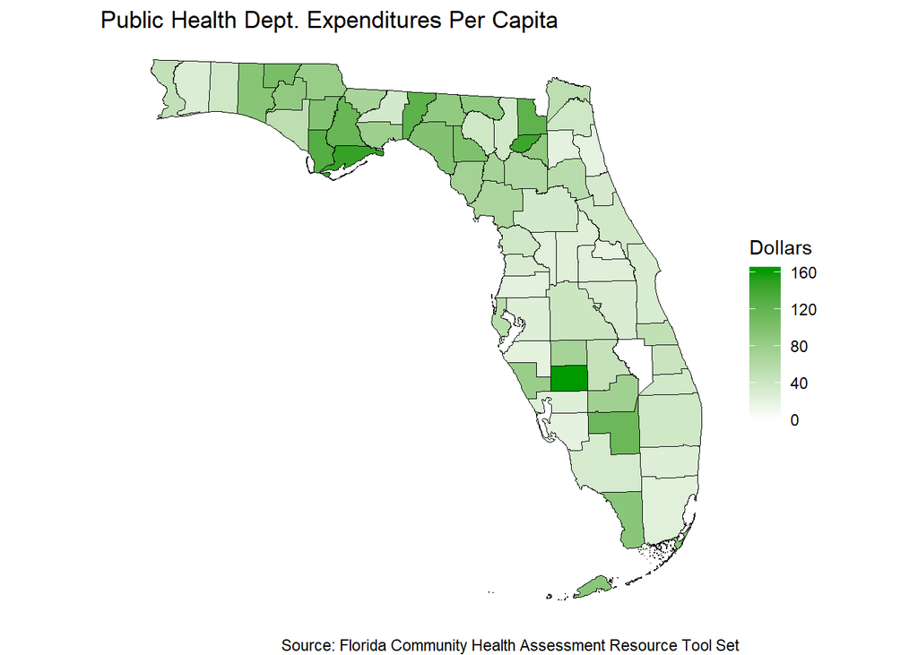

## Employees

The standardized measure (per 100,000) provides a more easily comparable look between counties than raw, absolute data. However, in the future, as with the above expenditures map, it would not hurt to also have those graphics for reference in comparing sheer population differences. From what I can tell from the map above, as well as other knowledge, it seems like this case is similar to that of physicians, in that there is not proportional understaffing of workers in the health field per county. For example, a rural county only having 8-10 public health employees might not seem like a lot, especially when a more urban county could have around 1,000 employees of this kind. But if taking into consideration the demand-side aspect of this distribution, this might be considered to be good coverage when also taking population and needs into account (8,000 versus 2,000,000) (Rechovsky & Staiti, 2005).

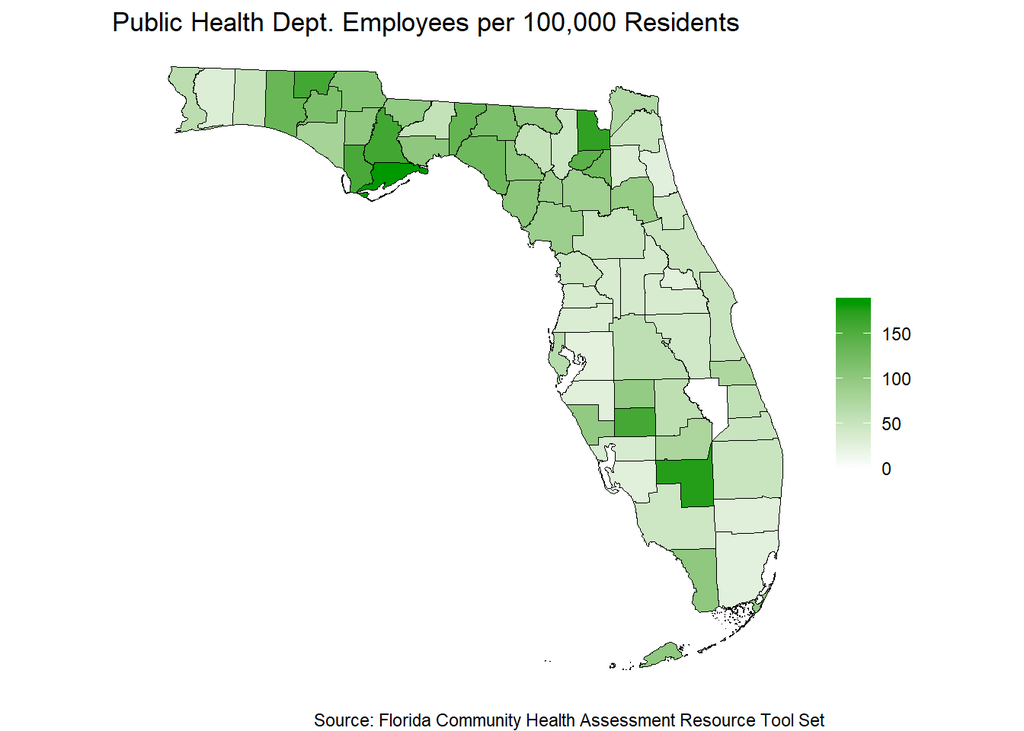

# Conclusion

These preliminary maps provide a good first look at the distribution of health care resources across Florida’s counties. My next report focuses on the health environments residents of Florida’s counties find themselves in, including air quality and heat exposure. If you have any questions, feel free to reach out to me at rory.renzy17@ncf.edu.

# Sources

2019 Physician Workforce Annual Report. (2019). [Link](http://www.floridahealth.gov/provider-and-partner-resources/community-health-workers/physician-workforce-development-and-recruitment/2019DOHPhysicianWorkforceReport-10-30-19.pdf)

Brooks, R. G., Mardon, R., & Clawson, A. (2003). The Rural Physician Workforce in Florida: A Suvey of US- and Foreign-Born Primary Care Physicians. *The Journal of Rural Health, 19:4*, 484-491. [Link](https://onlinelibrary.wiley.com/doi/abs/10.1111/j.1748-0361.2003.tb00586.x)

Laditka, J. N., Laditka, S. B., & Probst, J. C. (2009) Health care access in rural areas: Evidence that hopsitalization for ambulatory care-sensitive conditions in the United States may increase with level of rurality. *Health & Place, 15*, 761-770. [Link](https://www.sciencedirect.com/science/article/abs/pii/S1353829209000057)

Newhouse, J. P. (1990). Geographic Access to Physician Services. *Annual Review of Public Health, 11*, 207-230. [Link](https://www.annualreviews.org/doi/pdf/10.1146/annurev.pu.11.050190.001231)

Rechovsky, J. D., & Staiti, A. B. (2005). Physician Incomes in Rural and Urban America. *Center for Studying Health System Change, 92*. [Link](https://www.ahc.umn.edu/img/assets/18444/Physician%20Incomes%20in%20Rural%20and%20Urban%20America.pdf)